# Market Basket Analysis

Jae Kwan Koo

# Market Basket Analysis - Titanic

## 데이터 준비하기

```r
data(Titanic)

Titanic
```

```
## , , Age = Child, Survived = No
##
##       Sex
## Class  Male Female
##   1st     0      0
##   2nd     0      0
##   3rd    35     17
##   Crew    0      0
##
## , , Age = Adult, Survived = No
##
##       Sex
## Class  Male Female
##   1st   118      4
##   2nd   154     13
##   3rd   387     89
##   Crew  670      3
##
## , , Age = Child, Survived = Yes
##
##       Sex
## Class  Male Female
##   1st     5      1
##   2nd    11     13
##   3rd    13     14
##   Crew    0      0
##
## , , Age = Adult, Survived = Yes
##
##       Sex
## Class  Male Female
##   1st    57    140
##   2nd    14     80
##   3rd    75     76
##   Crew  192     20
```

R에 내장된 Titanic데이터셋은 3원분할표로 이루어져있다.  
이 형태를 데이터프레임 형태로 바꿔서보자.

```r
titanic.df <- as.data.frame(Titanic)

head(titanic.df)
```

|  | Class | Sex | Age | Survived | Freq |
| --- | --- | --- | --- | --- | --- |
| 1 | 1st | Male | Child | No | 0 |
| 2 | 2nd | Male | Child | No | 0 |
| 3 | 3rd | Male | Child | No | 35 |
| 4 | Crew | Male | Child | No | 0 |
| 5 | 1st | Female | Child | No | 0 |
| 6 | 2nd | Female | Child | No | 0 |

```r
summary(titanic.df)
```

```
##   Class       Sex        Age     Survived      Freq
##  1st :8   Male  :16   Child:16   No :16   Min.   :  0.00
##  2nd :8   Female:16   Adult:16   Yes:16   1st Qu.:  0.75
##  3rd :8                                   Median : 13.50
##  Crew:8                                   Mean   : 68.78
##                                           3rd Qu.: 77.00
##                                           Max.   :670.00
```

빈도수와 함께 좌석의 클래스, 성별, 연령대, 생존여부 등이 표현되고 있다. 이 빈도들에 대해 전부 풀어서 데이터프레임을 다시 만들어보자.

```r
titanic <- NULL

for(i in 1:4){
  titanic <-
  cbind( titanic,rep(as.character(titanic.df[,i]), titanic.df$Freq) )
}


titanic <- as.data.frame(titanic)
names(titanic) <- names(titanic.df)[1:4]


titanic
```

| Class | Sex | Age | Survived |
| --- | --- | --- | --- |
| 3rd | Male | Child | No |
| 3rd | Male | Child | No |
| 3rd | Male | Child | No |
| 3rd | Male | Child | No |
| 3rd | Male | Child | No |
| 3rd | Male | Child | No |
| 3rd | Male | Child | No |
| 3rd | Male | Child | No |
| 3rd | Male | Child | No |
| 3rd | Male | Child | No |

[output cut: 2191 more lines]

빈도와 함께 표현된 데이터셋의 열에 대해 Freq만큼 반복하여 풀어주고 있다.  
이제 빈도에 대한 열은 나타나지않고 그 반복수만큼 행이 늘어난 모습이다.  
컬럼이름은 이전의 것을 가져왔다.

## Library

```r
library(arules)
library(arulesViz)
```

## apriori 알고리즘

```r
options(digits=3) # 소수점 3째자리까지만 표현

# 모든 규칙 생성
rules.all <- apriori(titanic)
```

```
## Apriori
##
## Parameter specification:
##  confidence minval smax arem  aval originalSupport maxtime support minlen
##         0.8    0.1    1 none FALSE            TRUE       5     0.1      1
##  maxlen target  ext
##      10  rules TRUE
##
## Algorithmic control:
##  filter tree heap memopt load sort verbose
##     0.1 TRUE TRUE  FALSE TRUE    2    TRUE
##
## Absolute minimum support count: 220
##
## set item appearances ...[0 item(s)] done [0.00s].
## set transactions ...[10 item(s), 2201 transaction(s)] done [0.00s].
## sorting and recoding items ... [9 item(s)] done [0.00s].
## creating transaction tree ... done [0.00s].
## checking subsets of size 1 2 3 4 done [0.00s].
## writing ... [27 rule(s)] done [0.00s].
## creating S4 object  ... done [0.00s].
```

27개의 규칙이 발견되었다.

```r
inspect(rules.all)
```

```
##      lhs                                   rhs           support
## [1]  {}                                 => {Age=Adult}   0.950
## [2]  {Class=2nd}                        => {Age=Adult}   0.119
## [3]  {Class=1st}                        => {Age=Adult}   0.145
## [4]  {Sex=Female}                       => {Age=Adult}   0.193
## [5]  {Class=3rd}                        => {Age=Adult}   0.285
## [6]  {Survived=Yes}                     => {Age=Adult}   0.297
## [7]  {Class=Crew}                       => {Sex=Male}    0.392
## [8]  {Class=Crew}                       => {Age=Adult}   0.402
## [9]  {Survived=No}                      => {Sex=Male}    0.620
## [10] {Survived=No}                      => {Age=Adult}   0.653
## [11] {Sex=Male}                         => {Age=Adult}   0.757
## [12] {Sex=Female,Survived=Yes}          => {Age=Adult}   0.144
## [13] {Class=3rd,Sex=Male}               => {Survived=No} 0.192
## [14] {Class=3rd,Survived=No}            => {Age=Adult}   0.216
```

[output cut: 41 more lines]

규칙의 우변(rhs)이 생존 여부(Survived)와 관계된 규칙이다.

```r
rules <- apriori(titanic,
                 control = list(verbose=F),
                 parameter = list(minlen=2, supp=0.005, conf=0.8),
                 appearance = list(rhs=c("Survived=No", "Survived=Yes"),
                                   default="lhs"))
```

- 최소부분집합크기 : 2
- 최소지지도 : 0.005
- 최소신뢰도 : 0.8

옵션을 새롭게 한 뒤 다시 규칙을 살펴보기로 했다.

```r
inspect(rules)
```

```
##      lhs                                  rhs            support
## [1]  {Class=2nd,Age=Child}             => {Survived=Yes} 0.01090
## [2]  {Class=2nd,Sex=Female}            => {Survived=Yes} 0.04225
## [3]  {Class=2nd,Sex=Male}              => {Survived=No}  0.06997
## [4]  {Class=1st,Sex=Female}            => {Survived=Yes} 0.06406
## [5]  {Class=Crew,Sex=Female}           => {Survived=Yes} 0.00909
## [6]  {Class=3rd,Sex=Male}              => {Survived=No}  0.19173
## [7]  {Class=2nd,Sex=Female,Age=Child}  => {Survived=Yes} 0.00591
## [8]  {Class=2nd,Sex=Female,Age=Adult}  => {Survived=Yes} 0.03635
## [9]  {Class=2nd,Sex=Male,Age=Adult}    => {Survived=No}  0.06997
## [10] {Class=1st,Sex=Female,Age=Adult}  => {Survived=Yes} 0.06361
## [11] {Class=Crew,Sex=Female,Age=Adult} => {Survived=Yes} 0.00909
## [12] {Class=3rd,Sex=Male,Age=Adult}    => {Survived=No}  0.17583
##      confidence coverage lift count
## [1]  1.000      0.01090  3.10  24
## [2]  0.877      0.04816  2.72  93
## [3]  0.860      0.08133  1.27 154
## [4]  0.972      0.06588  3.01 141
## [5]  0.870      0.01045  2.69  20
## [6]  0.827      0.23171  1.22 422
## [7]  1.000      0.00591  3.10  13
## [8]  0.860      0.04225  2.66  80
## [9]  0.917      0.07633  1.35 154
## [10] 0.972      0.06542  3.01 140
## [11] 0.870      0.01045  2.69  20
## [12] 0.838      0.20990  1.24 387
```

12개의 규칙들이 발견되었다.

```r
rules.sorted <- sort(rules, by="lift") # 향상도(lift) 기준으로 정렬

inspect(rules.sorted)
```

```
##      lhs                                  rhs            support
## [1]  {Class=2nd,Age=Child}             => {Survived=Yes} 0.01090
## [2]  {Class=2nd,Sex=Female,Age=Child}  => {Survived=Yes} 0.00591
## [3]  {Class=1st,Sex=Female}            => {Survived=Yes} 0.06406
## [4]  {Class=1st,Sex=Female,Age=Adult}  => {Survived=Yes} 0.06361
## [5]  {Class=2nd,Sex=Female}            => {Survived=Yes} 0.04225
## [6]  {Class=Crew,Sex=Female}           => {Survived=Yes} 0.00909
## [7]  {Class=Crew,Sex=Female,Age=Adult} => {Survived=Yes} 0.00909
## [8]  {Class=2nd,Sex=Female,Age=Adult}  => {Survived=Yes} 0.03635
## [9]  {Class=2nd,Sex=Male,Age=Adult}    => {Survived=No}  0.06997
## [10] {Class=2nd,Sex=Male}              => {Survived=No}  0.06997
## [11] {Class=3rd,Sex=Male,Age=Adult}    => {Survived=No}  0.17583
## [12] {Class=3rd,Sex=Male}              => {Survived=No}  0.19173
##      confidence coverage lift count
## [1]  1.000      0.01090  3.10  24
## [2]  1.000      0.00591  3.10  13
## [3]  0.972      0.06588  3.01 141
## [4]  0.972      0.06542  3.01 140
## [5]  0.877      0.04816  2.72  93
## [6]  0.870      0.01045  2.69  20
## [7]  0.870      0.01045  2.69  20
## [8]  0.860      0.04225  2.66  80
## [9]  0.917      0.07633  1.35 154
## [10] 0.860      0.08133  1.27 154
## [11] 0.838      0.20990  1.24 387
## [12] 0.827      0.23171  1.22 422
```

첫 줄에서 클래스가 2등석이면서 연령대가 Child이면 생존한다는 규칙은 클래스가 2등석이면서 여성이고 Child이면 생존한다라는 규칙을 포함한다. 즉, 중복되는 규칙들이 존재한다.  
중복되는 규칙들을 찾아보자.

### 중복되는 규칙 제거

```r
subset.matrix <- is.subset(rules.sorted, rules.sorted)
```

12개의 규칙이 존재하는 rules.sorted변수에 대해 중복되는 규칙 찾을 것이다. 12*12 행렬 (12개규칙임을 위에서 알았다)

`is.subset()`함수는 subset인지 확인하는 것이다. 자기 자신은 자기 자신의 부분집합이니까 subset에 포함이 된다.

- **|** : subset이 맞음
- **.** : subset이 아님

|과 .은 각각 1과 0을 의미한다.

예를 들면, 아까처럼 두번째 규칙은 첫번째 규칙에 포함되니까 (1,2)원소가 |이다. 하지만 첫번째 규칙은 두번째 규칙의 subset이 아니니까 .이다.

```r
subset.matrix[subset.matrix==diag(12)] <- F

redundant <- colSums(subset.matrix, na.rm = T) >= 1
which(redundant)
```

```
##  {Class=2nd,Sex=Female,Age=Child,Survived=Yes}
##                                              2
##  {Class=1st,Sex=Female,Age=Adult,Survived=Yes}
##                                              4
## {Class=Crew,Sex=Female,Age=Adult,Survived=Yes}
##                                              7
##  {Class=2nd,Sex=Female,Age=Adult,Survived=Yes}
##                                              8
##     {Class=2nd,Sex=Male,Age=Adult,Survived=No}
##                                              9
##     {Class=3rd,Sex=Male,Age=Adult,Survived=No}
##                                             11
```

```r
# 중복되는 규칙 삭제
rules.pruned <- rules.sorted[!redundant]

inspect(rules.pruned)
```

```
##     lhs                        rhs            support confidence coverage
## [1] {Class=2nd,Age=Child}   => {Survived=Yes} 0.01090 1.000      0.0109
## [2] {Class=1st,Sex=Female}  => {Survived=Yes} 0.06406 0.972      0.0659
## [3] {Class=2nd,Sex=Female}  => {Survived=Yes} 0.04225 0.877      0.0482
## [4] {Class=Crew,Sex=Female} => {Survived=Yes} 0.00909 0.870      0.0104
## [5] {Class=2nd,Sex=Male}    => {Survived=No}  0.06997 0.860      0.0813
## [6] {Class=3rd,Sex=Male}    => {Survived=No}  0.19173 0.827      0.2317
##     lift count
## [1] 3.10  24
## [2] 3.01 141
## [3] 2.72  93
## [4] 2.69  20
## [5] 1.27 154
## [6] 1.22 422
```

## Visualization

### Scatter plot

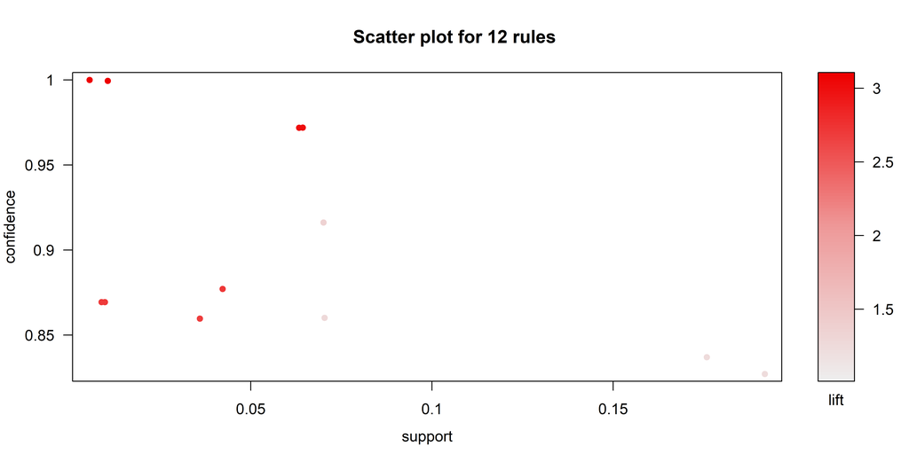

```r
plot(rules.sorted)
```

default option : measure = c(“support”, “confidence”), shading=“lift”

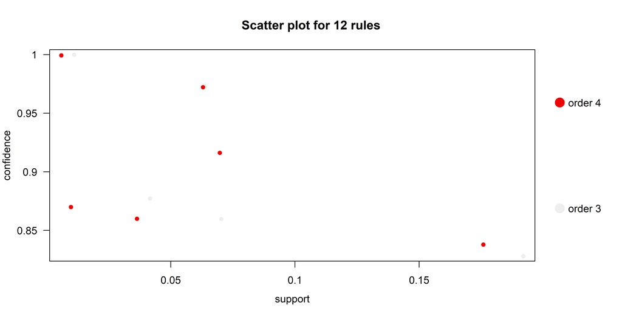

```r
plot(rules.sorted, shading="order")
```

```r
# interactive
# 선택된 규칙을 조사(inspect), 줌인(줌아웃), 규칙 필터링(color key에서 절단값 클릭)

# plot(rules.sorted, measure=c("support", "lift"), shading="confidence", interactive=TRUE)
```

### Graph

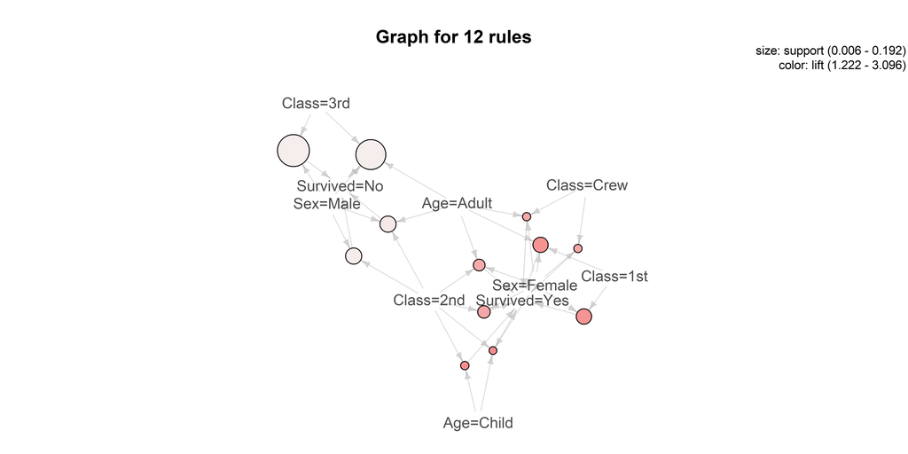

```r
plot(rules.sorted, method="graph")
```

```r
# 각 원의 크기가 support, 색의 진하기가 lift, grouped나 graph나 confidence는 모두 빠져있다는 단점도 있다.
```

### Grouped matrix plot

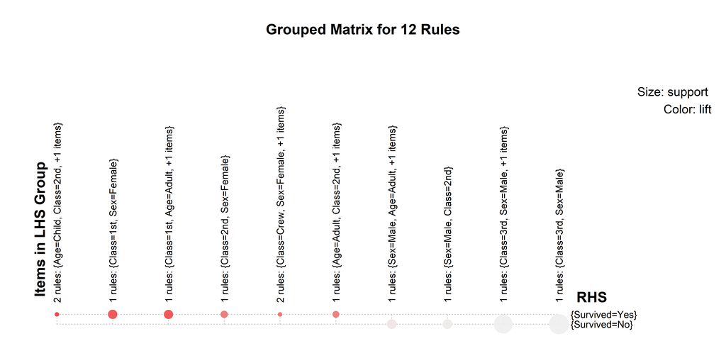

```r
plot(rules.sorted, method="grouped") # 생략된 아이템이 +1items라고 표현되고 있음
```

### Parallel coordinates plot

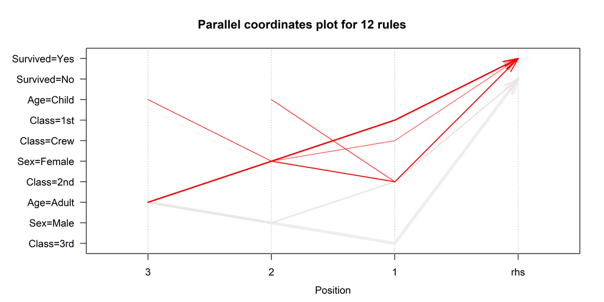

```r
# 평행좌표그림

plot(rules.sorted, method="paracoord", control=list(reorder=TRUE))
```

3,2,1 : lhs를 지칭  
선의 굵기 : 지지도  
선의 진하기 : 향상도

### Matrix plot

```
## Itemsets in Antecedent (LHS)
##  [1] "{Class=2nd,Age=Child}"
##  [2] "{Class=2nd,Sex=Female,Age=Child}"
##  [3] "{Class=1st,Sex=Female}"
##  [4] "{Class=1st,Sex=Female,Age=Adult}"
##  [5] "{Class=2nd,Sex=Female}"
##  [6] "{Class=Crew,Sex=Female}"
##  [7] "{Class=Crew,Sex=Female,Age=Adult}"
##  [8] "{Class=2nd,Sex=Female,Age=Adult}"
##  [9] "{Class=2nd,Sex=Male,Age=Adult}"
## [10] "{Class=2nd,Sex=Male}"
## [11] "{Class=3rd,Sex=Male,Age=Adult}"
## [12] "{Class=3rd,Sex=Male}"
## Itemsets in Consequent (RHS)
## [1] "{Survived=No}"  "{Survived=Yes}"
```

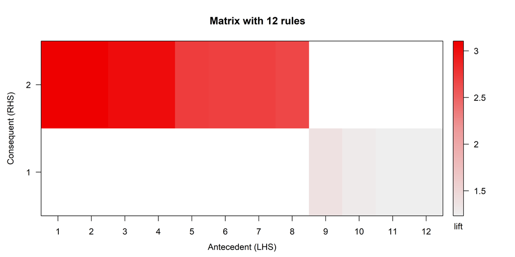

```r
## 행렬-기반 시각화
plot(rules.sorted, method="matrix", measure="lift")
```

```
## Itemsets in Antecedent (LHS)
##  [1] "{Class=2nd,Age=Child}"
##  [2] "{Class=2nd,Sex=Female,Age=Child}"
##  [3] "{Class=1st,Sex=Female}"
##  [4] "{Class=1st,Sex=Female,Age=Adult}"
##  [5] "{Class=2nd,Sex=Female}"
##  [6] "{Class=Crew,Sex=Female}"
##  [7] "{Class=Crew,Sex=Female,Age=Adult}"
##  [8] "{Class=2nd,Sex=Female,Age=Adult}"
##  [9] "{Class=2nd,Sex=Male,Age=Adult}"
## [10] "{Class=2nd,Sex=Male}"
## [11] "{Class=3rd,Sex=Male,Age=Adult}"
## [12] "{Class=3rd,Sex=Male}"
## Itemsets in Consequent (RHS)
## [1] "{Survived=No}"  "{Survived=Yes}"
```

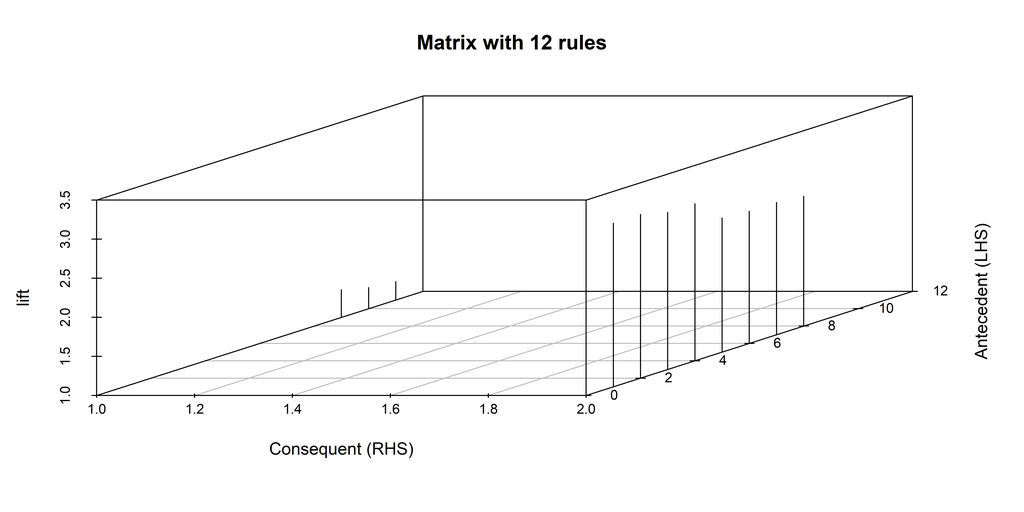

```r
plot(rules.sorted, method="matrix3D", measure="lift")
```